# Dashboard: Uptake

Barplots

Carlos Guío

2021-12-11

## Read and prepare Q1 datasets

Q1 datasets are loaded by sourcing the `Prepare_Uptake_Barplot.R`script. These datasets were designed to answer the questions:

- Who adopted/disadopted practices and why?
- Who accessed/used climate information services?

The Q1_practices and Q1_services datasets were lightly processed to make them compatible among them.

```r
library(devtools)

source_url("https://raw.githubusercontent.com/cmguiob/CSA_Dashboard/main/R/Prepare_Uptake_Barplot.R")
```

## Visualizations

The following chunks contain the code that was used to creat the graphics on the **uptake** page of the dashboard, namely a barplot and a map.

### Visaulization choice: maps of selected sites

In the next chuck you will find a function that allows to map the locations where a given practice or service was implemented/used. The location argument is optional and must be given by site.

```r
f_map <- function(dataset = uptake_dat, CSA_category, type, subtype, year_1, year_2, location = uptake_dat$site){

  library(ggplot2)
  library(tidyverse)
  library(ggrepel)

  # Error messages
  if (!CSA_category %in% c("Practices", "Services"))
    stop("use either Practices or Services as CSA_category")

  if (!type %in% dataset$practice_type)
    stop("assign a valid practice type")

  if (!subtype %in% dataset$subtype)
    stop("assign a valid practice subtype")


  dataset <- dataset %>%
             filter(option == CSA_category,
                    year >= year_1 & year <= year_2 ,
                    practice_type == type,
                    subtype == subtype)

  if (!missing(location)) {
    dataset <- dataset %>% filter(site %in% location)
    if (!location %in% dataset$site)
    stop("assign a valid site name as location")
  }


  world_data <- ggplot2::map_data('world')%>%
  rename(country = region) %>%
  select(-subregion) %>%
  filter(country %in% dataset$country)


  ggplot(data = world_data,
       aes(x = long,
           y = lat)) +
    geom_polygon(data = world_data,
               aes(group = group),
               color = "#faf9f5",
               fill = "#ECEBE7",
               size = 1) +
    geom_point(data = dataset,
             aes(x = longitude_site,
                 y = latitude_site),
             shape = 19,
             size = 3,
             alpha = 0.8,
             color = "#B8B7B3") +
    geom_text_repel(data = dataset %>%
                    ungroup() %>%
                    distinct(site, .keep_all = TRUE),
                  aes(label = site,
                      x = longitude_site,
                      y = latitude_site),
                  size = 5,
                  fontface = "bold",
                  box.padding = 0.1,
                  point.padding = 0.1,
                  nudge_y = 0,
                  max.overlaps = Inf,
                  direction = "both",
                  xlim = c(-Inf, Inf),
                  alpha = 0.5) +
    guides(color = "none")+
    theme_minimal()+
    theme(panel.grid = element_blank(),
          # Optional background color as in dashboard
          #plot.background = element_rect(fill = "#faf9f5", color = "#faf9f5"),
          axis.text = element_blank(),
          axis.title = element_blank(),
          plot.margin=unit(c(0,20,0,20), "mm"))+
  coord_quickmap(clip = "off")

}
```

The argumens of the function take in values similar to the drop down menus used in the PBI-dashboard. To export it, first store it as an object. The `location` argument is optional: if not given, all places will be shown for the practice and years; alternatively, one or more places can be selected.

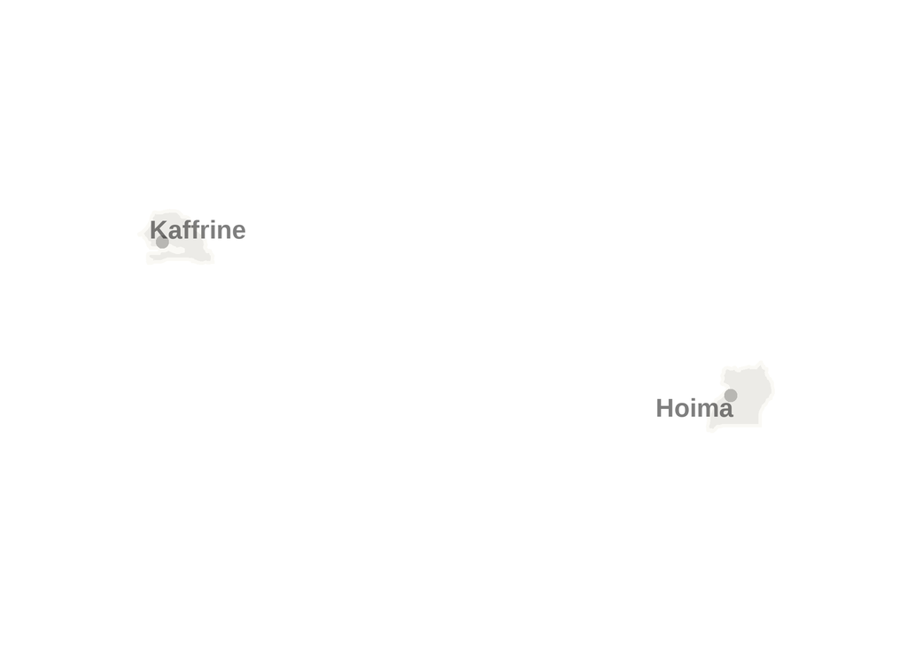

```r
p_map <- f_map(CSA_category = "Practices", type = "Agroforestry", subtype = "Tree planting", year_1 = 2019, year_2 = 2021, location = c("Kaffrine", "Hoima"))

p_map
```

```r
# Export
#ggsave(file = "p_map.png", plot = p_map, device = "png", type = "cairo", path = "Input a path from your PC, dpi = 300, width = 9.5, height = 5)
```

### Visualization choice: barplot with `ggplot` (CRAN), faceted by site and year.

According to Claus Wilke, humans are better perceiving distances over areas. Therefore, a barchart is decoded easier than a pie chart or a mosaic plot. In this case, the bar segments are related to implementation and use cases (of practices and services) of farmers at a given site.

In the first chunk of this section the code creates a function to create a barplot for a location, practice type, practice subtype, year interval and CSA_category of choice.

```r
f_barplot <- function(dataset = uptake_dat, CSA_category, type, subtype, year_1, year_2, location = uptake_dat$site){

  library(tidyverse)
  library(ggplot2)
  library(ggrepel)

  # Error messages
  if (!CSA_category %in% c("Practices", "Services"))
    stop("use either Practices or Services as CSA_category")

  if (!type %in% dataset$practice_type)
    stop("assign a valid practice type")

  if (!subtype %in% dataset$subtype)
    stop("assign a valid practice subtype")

  years <- dataset %>% ungroup() %>%
  filter(site %in% location, option == CSA_category, practice_type == type, subtype == subtype) %>%            select(year) %>%
  distinct()

  if (!any(range(years) %in% seq(year_1, year_2, by=1)))
    stop("assign a valid year interval to the surveyed site")

  if (!missing(location)) {
    dataset <- dataset %>% filter(site %in% location)
    if (!location %in% dataset$site)
    stop("assign a valid site name as location")
  }

  dat <- dataset %>%
  # Filter by location type (this will be a selection box in PBI)
  filter(site %in% location,
         option == CSA_category,
         year >= year_1 & year <= year_2,
         practice_type == type,
         subtype == subtype) %>%
  # Assign levels to adopted cases
  mutate(adopted_cases = factor(adopted_cases, levels = c("Implemented",
                                                 "Stopped implementing",
                                                 "Know about it",
                                                 "Heard about it",
                                                 "Never heard about it",
                                                 "Accessed and used it",
                                                 "Accessed but didn't use it")))%>%
  group_by(year, site, practice_type, subtype, gender, n_site) %>%
  # Filter out 0 values
  filter(n != 0)%>%
  # Create graphic variables
  mutate(gender_n = paste(substr(gender,1,1), paste0("(",n_site,")"), sep = "\n"))%>%
  arrange(year, site, practice_type, subtype, gender, desc(adopted_cases)) %>%
  mutate(pos = cumsum(n) - (0.5 * n)) %>%
  group_by(site) %>%
  mutate(x = case_when(any(str_detect(gender, "Female"))& gender == "Female"~ 0.6,
                       any(str_detect(gender, "Female"))& gender == "Male"~ 1.6,
                       any(!str_detect(gender, "Female"))& gender == "Male"~ 0.6),
         xend = case_when(any(str_detect(gender, "Female"))& gender == "Female"~ 1.4,
                       any(str_detect(gender, "Female"))& gender == "Male"~ 2.4,
                       any(!str_detect(gender, "Female"))& gender == "Male"~ 1.4))

    #Plot
    ggplot(dat,
           aes(fill = adopted_cases, y = n, x = gender_n)) +
    geom_bar(position="stack", stat="identity", alpha = 0.8)+
    geom_label_repel(data = dat,
                aes(label = paste0(round(percentage,0),"%"),
                x = gender_n,
                y = pos,
                color = adopted_cases),
            show.legend=F,
            size = 2.5, #adjust size of percentage labels
            alpha = 0.8,
            force = 0.1,
            box.padding = 0.1,
            direction = "x",
            max.overlaps = Inf,
            fill = "white")+
    geom_segment(data = dat,
               aes(x = x,
                   xend = xend,
                   y = n_site,
                   yend = n_site),
               linetype=2, color = "#B8B7B3")+
    facet_grid(year ~ site, scales = "free_x", space = "free_x") +
    scale_y_continuous(labels = scales::percent_format()) +
    scale_fill_manual(values = c("#9ACD32", "#C67171", "#b5b0b0","#CDC9C9", "#E6E1E1"))+
    scale_color_manual(values = c("#9ACD32", "#C67171",  "#b5b0b0","#CDC9C9", "#E6E1E1"))+
    # Optional fills
    #scale_fill_OkabeIto(order = c(3,4, 1,2))+
    #scale_fill_hue(l = 70, c = 45, h = c(95,360))+
    #scale_color_hue(l = 70, c = 45, h = c(95,360))+
    guides(fill = guide_legend(override.aes = list(size = 7),
                            title.position = "bottom",
                            title = ifelse(dat$option == "Practices",
                                           "* Greyscale: not implemented", "")))+
  theme_minimal()+
    theme(panel.grid = element_blank(),
        # Optional background colors like in the dashboard
        #panel.background = element_rect(fill = "#faf9f5", color = "#ECEBE7", size = 1 ),
        #plot.background = element_rect(fill = "#faf9f5", color = "#faf9f5"),
        strip.background = element_rect(fill = "#ECEBE7", color = "#ECEBE7"),
        #adjust size of facet header text
        strip.text.x = element_text(margin = margin(1.5,0,1.5,0, "mm"), size = 11, color = "#5D5C58"),
        strip.text.y = element_text(margin = margin(0,1.5,0,1.5, "mm"), size = 11, color = "#5D5C58"),
        legend.title = element_text(size = 7, margin = margin(5,0,0,0, "mm")),
        legend.key.size = unit(1.5, 'lines'),
        legend.justification = "top",
        legend.position = "left",
        #adjust size of legend text
        legend.text = element_text(size = 9, color = "#5D5C58"),
        axis.title = element_blank(),
        axis.text.y = element_blank(),
        #adjust size of axis text
        axis.text.x = element_text(size = 9, color = "#B8B7B3", vjust = -2),
        plot.margin=unit(c(5,10,10,5), "mm"))

}
```

#### Use the function to create a barplot

The argumens of the function take in values similar to the drop down menus used in the PBI-dashboard. Although the `location` argument is optional it is recommended to use it, as it will improve the readability of the graphic; for the best experience, input a maximum of three sites.

To export it, first store it as an object.

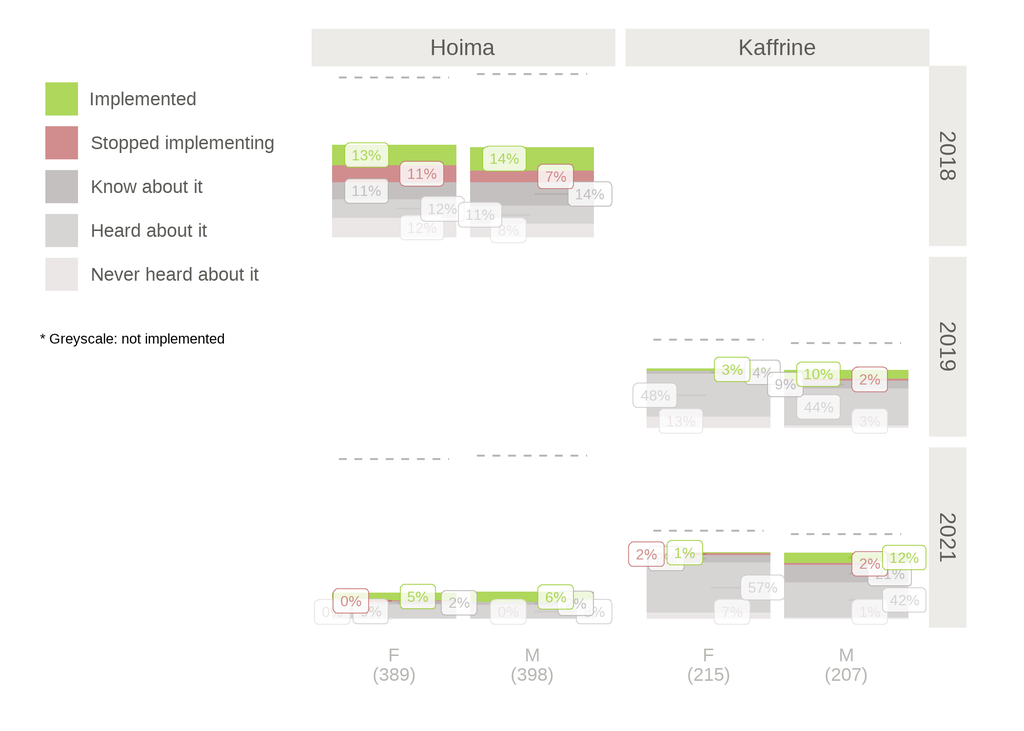

```r
p_barplot <- f_barplot(CSA_category = "Practices", type = "Agroforestry", subtype = "Tree planting", year_1 = 2018, year_2 = 2021, location =  c("Hoima","Kaffrine"))

p_barplot
```

```r
# Export
#ggsave(file = "p_barplot.png", plot = p_barplot, device = "png", type = "cairo", path = "Input a path from your PC, dpi = 300, width = 9.5, height = 5)
```

### Second visualization (alternative): barplot with `ggplot` (CRAN), faceted by practice subtype and year.

This is an alternative visualization option not used in PBI, but useful for the static reports, since it displays several practices for a given site.

In the first chunk of this section the code creates a function to create a barplot for a location, practice type, practice subtype, year interval and CSA_category of choice.

```r
f_barplot_2 <- function(dataset = uptake_dat, CSA_category, location, type = uptake_dat$practice_type,
                        subtype = uptake_dat$subtype,  year_1, year_2, top = FALSE){

  library(tidyverse)
  library(ggplot2)
  library(ggrepel)
  library(ggh4x)

  # Error messages
  if (!CSA_category %in% c("Practices", "Services"))
    stop("use either Practices or Services as CSA_category")

  if (location != dataset$site)
    stop("assign a valid site name as location")

  years <- dataset %>% ungroup() %>%
  filter(site == location, option == CSA_category, practice_type %in% type, subtype %in% subtype) %>%            select(year) %>%
  distinct()

  if (!any(range(years) %in% seq(year_1, year_2, by=1)))
    stop("assign a valid year interval to the surveyed site")


  if (!missing(type)) {
    dataset <- dataset %>% filter(practice_type %in% type)
    if (!type %in% dataset$practice_type)
    stop("assign a valid practice type")
  }

  if (!missing(subtype)) {
    dataset <- dataset %>% filter(subtype %in% subtype)
    if (!subtype %in% dataset$subtype)
    stop("assign a valid practice subtype")
  }

  if (top == TRUE) {
    dataset <- dataset %>% filter(!is.na(top))
    if (!top %in% c(TRUE, FALSE))
    stop("please input wither TRUE or FALSE. With TRUE argument the top 3 practices are shown")
  }


  dat <- dataset %>%
  # Filter by location type (this will be a selection box in PBI)
  filter(site == location,
         option == CSA_category,
         year >= year_1 & year <= year_2,
         practice_type %in% type,
         subtype %in% subtype) %>%
  # Assign levels to adopted cases
  mutate(adopted_cases = factor(adopted_cases, levels = c("Implemented",
                                                 "Stopped implementing",
                                                 "Know about it",
                                                 "Heard about it",
                                                 "Never heard about it",
                                                 "Accessed and used it",
                                                 "Accessed but didn't use it")))%>%
  group_by(year, site, practice_type, subtype, gender, n_site) %>%
  # Filter out 0 values
  filter(n != 0)%>%
  filter(adopted_cases == "Implemented" | adopted_cases == "Stopped implementing") %>%
  # Create graphic variables
  mutate(gender_n = paste(substr(gender,1,1), paste0("(",n_site,")"), sep = "\n"))%>%
  arrange(year, site, practice_type, subtype, gender, desc(adopted_cases)) %>%
  mutate(pos = cumsum(n) - (0.5 * n)) %>%
  group_by(site) %>%
  mutate(x = case_when(any(str_detect(gender, "Female"))& gender == "Female"~ 0.6,
                       any(str_detect(gender, "Female"))& gender == "Male"~ 1.6,
                       any(!str_detect(gender, "Female"))& gender == "Male"~ 0.6),
         xend = case_when(any(str_detect(gender, "Female"))& gender == "Female"~ 1.4,
                       any(str_detect(gender, "Female"))& gender == "Male"~ 2.4,
                       any(!str_detect(gender, "Female"))& gender == "Male"~ 1.4))


    #Plot
    ggplot(dat,
           aes(fill = adopted_cases, y = n, x = gender_n)) +
    geom_bar(position="stack", stat="identity", alpha = 0.8)+
    geom_label_repel(data = dat,
                aes(label = paste0(round(percentage,0),"%"),
                x = gender_n,
                y = pos,
                color = adopted_cases),
            show.legend=F,
            size = 2.5, #adjust size of percentage labels
            alpha = 0.8,
            force = 0.1,
            box.padding = 0.1,
            direction = "x",
            max.overlaps = Inf,
            fill = "white")+
    geom_segment(data = dat,
               aes(x = x,
                   xend = xend,
                   y = n_site,
                   yend = n_site),
               linetype=2, color = "#B8B7B3")+
    facet_nested(year ~ practice_type + subtype, scales = "free_x", space = "free_x") +
    scale_y_continuous(labels = scales::percent_format()) +
    scale_fill_manual(values = c("#9ACD32", "#C67171", "#b5b0b0","#CDC9C9", "#E6E1E1"))+
    scale_color_manual(values = c("#9ACD32", "#C67171",  "#b5b0b0","#CDC9C9", "#E6E1E1"))+
    # Optional fills
    #scale_fill_OkabeIto(order = c(3,4, 1,2))+
    #scale_fill_hue(l = 70, c = 45, h = c(95,360))+
    #scale_color_hue(l = 70, c = 45, h = c(95,360))+
    guides(fill = guide_legend(override.aes = list(size = 7),
                            title.position = "bottom",
                            title = ifelse(dat$option == "Practices",
                                           "* Greyscale: not implemented", "")))+
    theme_minimal()+
    theme(panel.grid = element_blank(),
        # Optional background colors like in the dashboard
        #panel.background = element_rect(fill = "#faf9f5", color = "#ECEBE7", size = 1 ),
        #plot.background = element_rect(fill = "#faf9f5", color = "#faf9f5"),
        strip.background = element_rect(fill = "#ECEBE7", color = "#ECEBE7"),
        #adjust size of facet header text
        strip.text.x = element_text(margin = margin(1.5,0,1.5,0, "mm"), size = 10, color = "#5D5C58"),
        strip.text.y = element_text(margin = margin(0,1.5,0,1.5, "mm"), size = 10, color = "#5D5C58"),
        legend.title = element_text(size = 7, margin = margin(5,0,0,0, "mm")),
        legend.key.size = unit(1.5, 'lines'),
        legend.justification = "top",
        legend.position = "left",
        #adjust size of legend text
        legend.text = element_text(size = 9, color = "#5D5C58"),
        axis.title = element_blank(),
        axis.text.y = element_blank(),
        #adjust size of axis text
        axis.text.x = element_text(size = 9, color = "#B8B7B3", vjust = -2),
        plot.margin=unit(c(5,10,10,5), "mm"))

}
```

#### Use the function to create a barplot

The argumens of the function take in values similar to the drop down menus used in the PBI-dashboard. Although the `type` argument is optional it is recommended to use it, as it will improve the readability of the graphic; for the best experience, input a maximum of two types of practices.

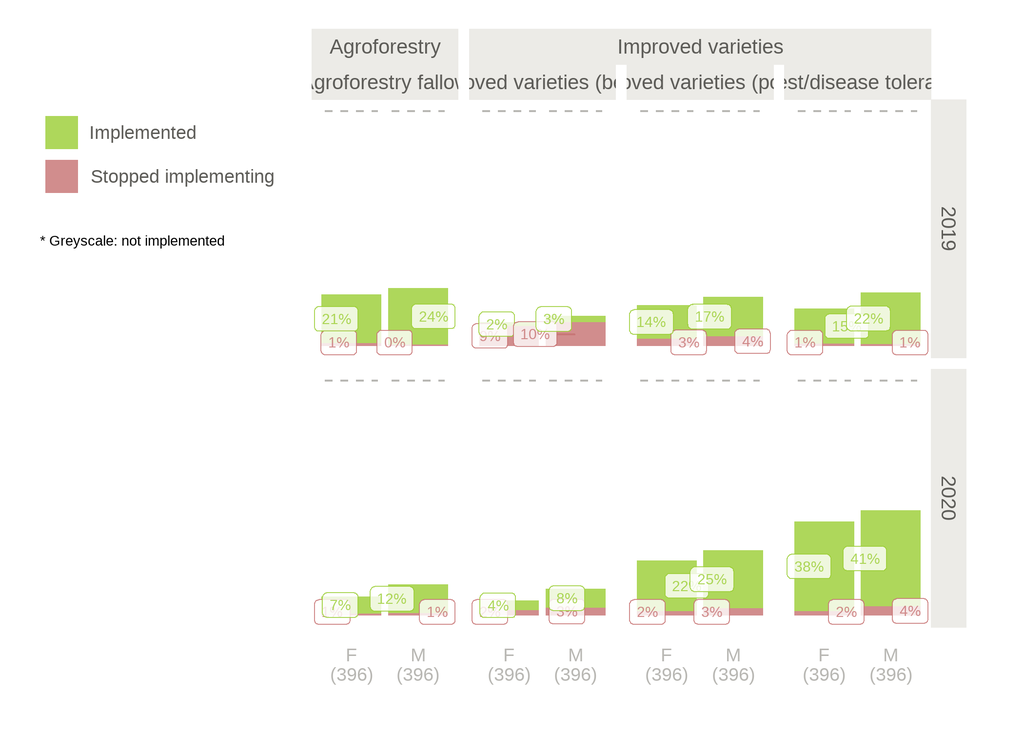

```r
p_barplot_2 <- f_barplot_2(CSA_category = "Practices", year_1 = 2018, year_2 = 2021, location = "Doyogena", type = c("Agroforestry", "Improved varieties"))

p_barplot_2
```

```r
# Export
#ggsave(file = "p_barplot.png", plot = p_barplot, device = "png", type = "cairo", path = "Input a path from your PC, dpi = 300, width = 9.5, height = 5)
```

`top`is also an optional argument: if used `top = TRUE`, it will display the top 3 most implemented practices. In that case `type`and `subtype`must be ignored.

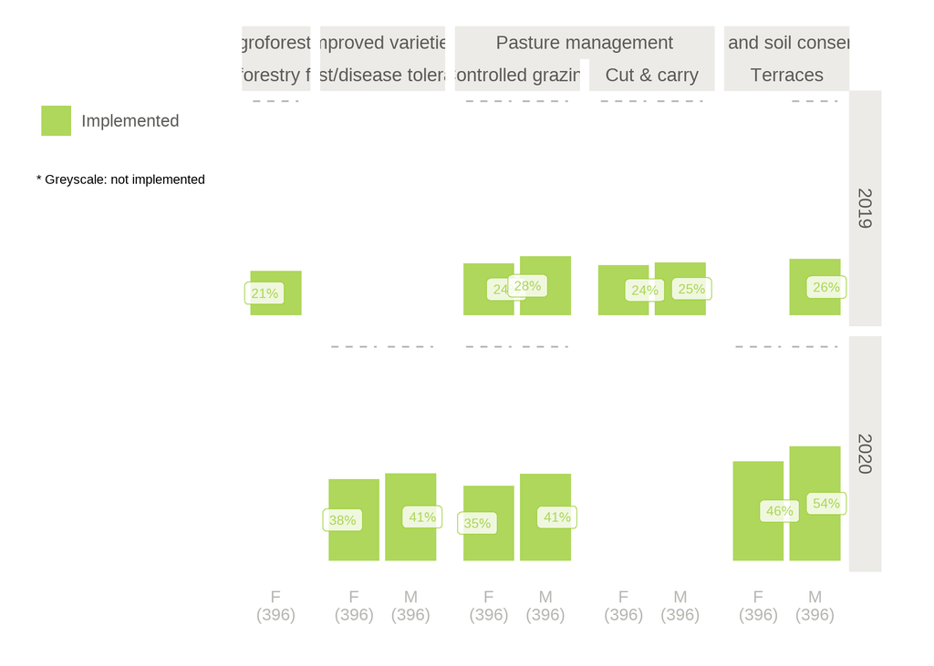

```r
p_barplot_3 <- f_barplot_2(CSA_category = "Practices", year_1 = 2018, year_2 = 2021, location = "Doyogena", top = TRUE)

p_barplot_3
```

```r
# Export
#ggsave(file = "p_barplot.png", plot = p_barplot, device = "png", type = "cairo", path = "Input a path from your PC, dpi = 300, width = 9.5, height = 5)
```